# Mock Exam — Statistics

2026-01-04

**Instructions**

- Answer directly in this file and knit to HTML or PDF at the end.
- Provide both **R output** and **short written interpretation** where requested.
- Total: **100 points**.

# 1 Part A — R Basics and Probability Theory (40 points)

## 1.1 A1. Data types and factors (7 points)

Create the following object and answer the questions.

```r
x <- c(1, 2, 2, 3, 3, 3)
g <- factor(c("A","B","A","B","B","A"))
df <- data.frame(x = x, g = g)
str(df)
```

```
## 'data.frame':    6 obs. of  2 variables:
##  $ x: num  1 2 2 3 3 3
##  $ g: Factor w/ 2 levels "A","B": 1 2 1 2 2 1
```

1. What does one **row** in `df` represent?

   *The value of x and g at the given index.*
2. How many observations are in group `A` and in group `B`?  
   *In group A and B are 3 observations each*
3. Compute the **mean of `x`** separately for each group.

   ```r
   Amean <- mean(df$x[df$g == "A"])
   Bmean <- mean(df$x[df$g == "B"])

   Amean
   ```

   ```
   ## [1] 2
   ```

   ```r
   Bmean
   ```

   ```
   ## [1] 2.666667
   ```

## 1.2 A2. Monte Carlo simulation (8 points)

Let $\Omega = \{1,2,\dots,100\}$. Draw $N=50{,}000$ values uniformly from $\Omega$ (with replacement). Estimate:

$$P(\text{multiple of 3} \mid \text{multiple of 3 or 5})$$

1. Compute the Monte Carlo estimate in R.

   ```r
   N <- 50000
   Omega <- sample(1:100,N,TRUE)

   p <- mean((Omega %% 3) == 0) / mean((Omega %% 3) == 0 | (Omega %% 5) == 0)

   p
   ```

   ```
   ## [1] 0.7034668
   ```

2. Compute the exact value by counting and compare.

## 1.3 A3. Sampling from a non-normal distribution (25 points)

The goal of this exercise is to illustrate the **Central Limit Theorem** using simulation.

Let $X \sim \text{Exponential}(\lambda = 1)$.

1. Draw $N = 10{,}000$ independent samples of size  
   $n = 5$, $n = 30$, and $n = 100$.

   ```r
   N <- 10000
   exn5 <- rexp(5,N)
   exn30 <- rexp(30,N)
   exn100 <- rexp(100,N)
   ```

2. For each $n$, compute the **sample mean**.

   ```r
   mexn5 <- mean(exn5)
   mexn30 <- mean(exn30)
   mexn100 <- mean(exn100)

   mexn5
   ```

   ```
   ## [1] 8.345355e-05
   ```

   ```r
   mexn30
   ```

   ```
   ## [1] 0.0001121928
   ```

   ```r
   mexn100
   ```

   ```
   ## [1] 0.0001054713
   ```

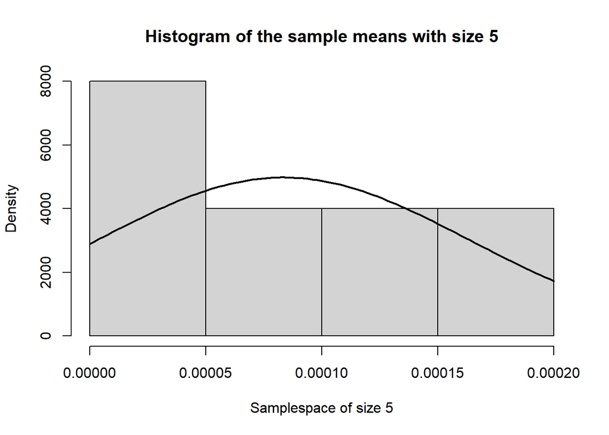

   ```r
   hist(exn5,freq = FALSE,breaks = 3,main = "Histogram of the sample means with size 5", xlab = "Samplespace of size 5")
   curve(dnorm(x, mean = mexn5, sd = sd(exn5)), add = TRUE , lwd = 2)
   ```

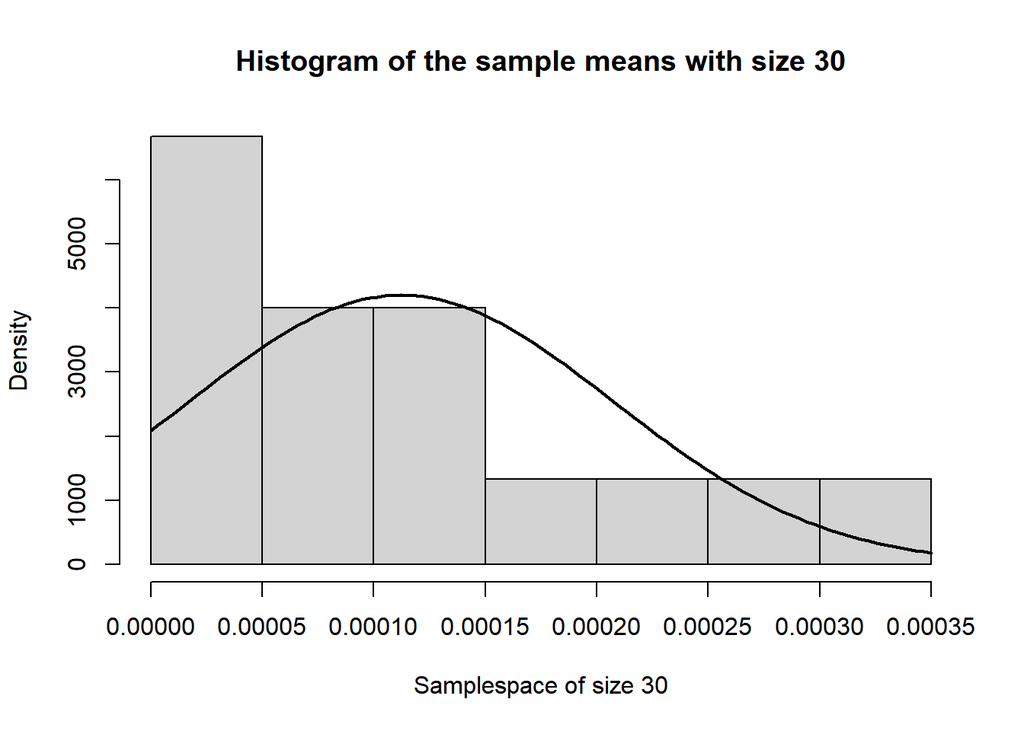

   ```r
   hist(exn30,freq = FALSE,10,main = "Histogram of the sample means with size 30", xlab = "Samplespace of size 30")
   curve(dnorm(x, mean = mexn30, sd = sd(exn30)), add = TRUE , lwd = 2)
   ```

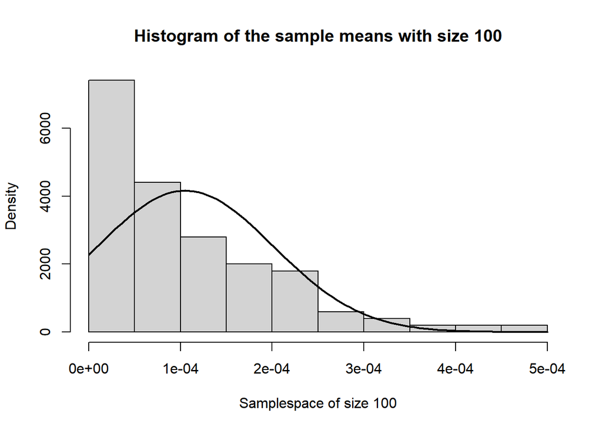

   ```r
   hist(exn100,freq = FALSE,10,main = "Histogram of the sample means with size 100", xlab = "Samplespace of size 100")
   curve(dnorm(x, mean = mexn100, sd = sd(exn100)), add = TRUE , lwd = 2)
   ```

5. For each sample size $n$, define the standardized mean

$$Z_n = \frac{\bar X_n - \mu}{\sigma / \sqrt{n}},$$

where $\mu$ and $\sigma$ are the true mean and standard deviation of the exponential distribution.

1. Compute $Z_n$ for $n = 5, 30, 100$.
2. Create histograms of $Z_n$ and compare them to the standard normal distribution.

Answer the following:

3. How does the distribution of $\bar X_n$ change as $n$ increases?

# 2 Part B — Descriptive statistics (45 points)

We use `birthwt` from the MASS package.

```r
library(MASS)
library(dplyr)
library(ggplot2)
library(forcats)

data(birthwt)

bwt <- birthwt %>%
  mutate(
    smoke = factor(smoke, levels = c(0,1), labels = c("No","Yes")),
    ht    = factor(ht, levels = c(0,1), labels = c("No","Yes")),
    ui    = factor(ui, levels = c(0,1), labels = c("No","Yes")),
    low   = factor(low, levels = c(0,1), labels = c("No","Yes"))
  )
```

## 2.1 B1. Variable overview (6 points)

1. In your own words: what does one row of `bwt` represent?

   *one measurement of a newborn baby with the Attributes low, age, lwt, race, smoke, ptl, ht, ui, ftv, bwt*
2. List **two categorical** and **two numeric** variables in `bwt`.

   categorical: low, smoke  
   numeric: age, lwt

## 2.2 B2. Histograms + ECDF (10 points)

For the numeric variable `bwt$bwt` (birth weight in grams):

1. Create two histograms with different bin widths (e.g. 150 and 400).

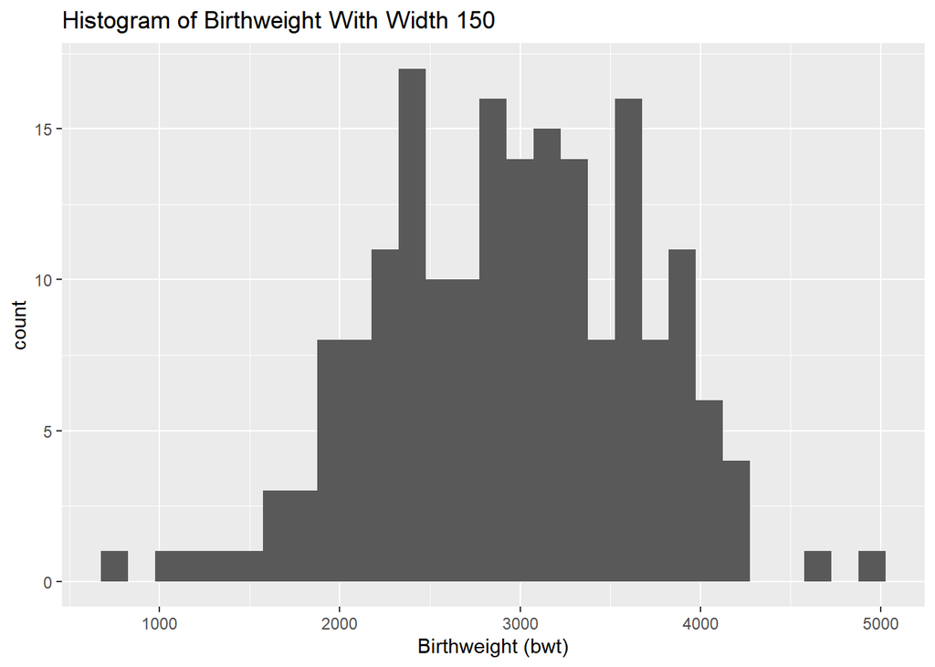

   ```r
   ggplot(bwt, aes(x = bwt))+
     geom_histogram(binwidth = 150)+
     labs(
       title = "Histogram of Birthweight With Width 150",
       x = "Birthweight (bwt)")
   ```

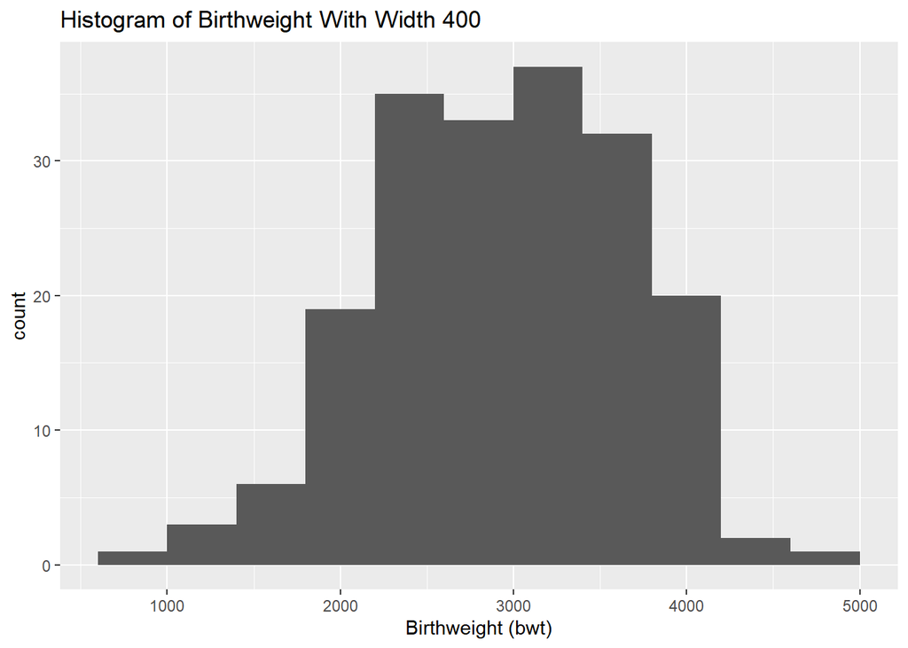

   ```r
   ggplot(bwt, aes(x = bwt))+
     geom_histogram(binwidth = 400)+
     labs(title = "Histogram of Birthweight With Width 400",
          x = "Birthweight (bwt)")
   ```

2. Create an ECDF plot.

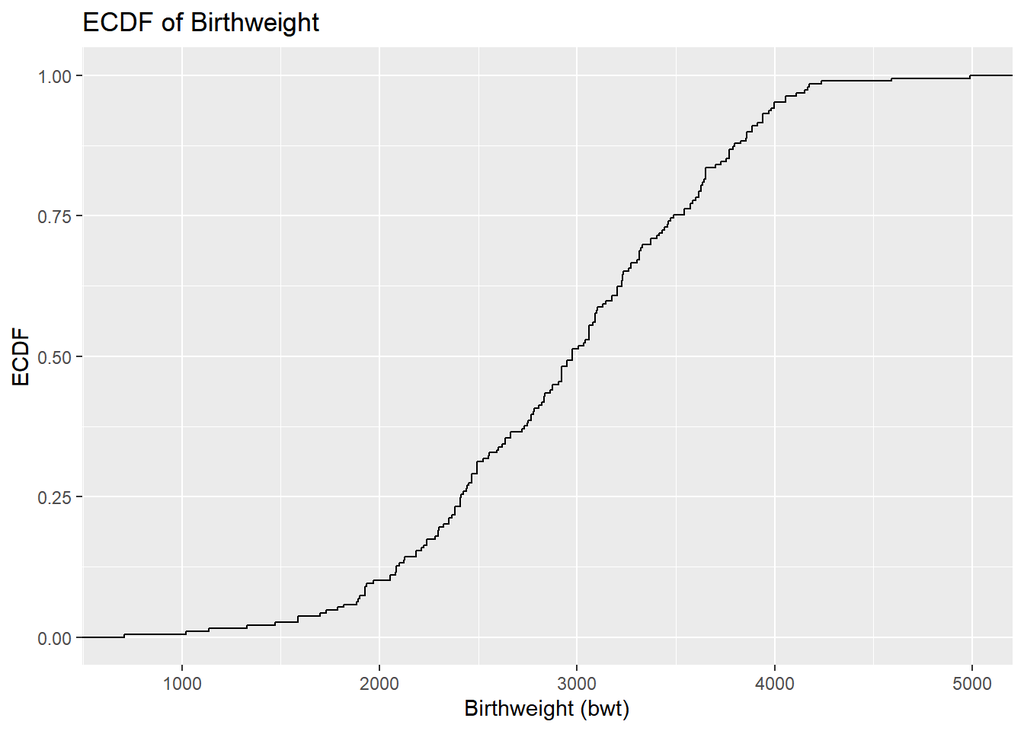

   ```r
   ggplot(bwt, aes(x = bwt))+
     stat_ecdf()+
     labs(
       title = "ECDF of Birthweight",
       x = "Birthweight (bwt)",
       y = "ECDF")
   ```

3. From the ECDF (or in R), estimate the proportion of babies with birth weight $\le 2500$ g. Write a sentence or two interpreting 1) how bin width affects the histogram and 2) what you see in the ECDF.

   ```r
   mean(bwt$bwt <= 2500)
   ```

   ```
   ## [1] 0.3121693
   ```

   If the bin width increases in a histogram it looses details.  
   The ECDF describes the data density for the birth weights, the middle of the data is at 3000g.

## 2.3 B3. Group comparison: smokers vs non-smokers (9 points)

1. Create a **boxplot** of `bwt` by `smoke`.

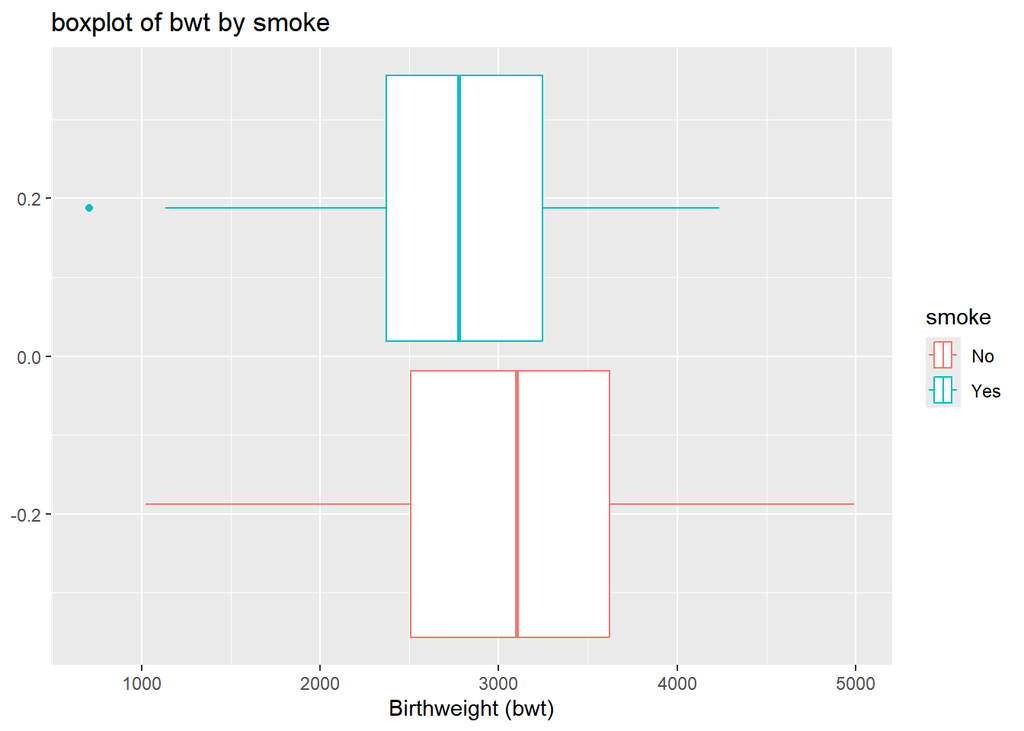

   ```r
   ggplot(bwt, aes(x = bwt, colour = smoke))+
     geom_boxplot()+
     labs(
       title = "boxplot of bwt by smoke",
       x = "Birthweight (bwt)")
   ```

2. Report the median birth weight for each group.

   ```r
   nonsmoke <- median(bwt$bwt[bwt$smoke == "No"])
   smoke <- median(bwt$bwt[bwt$smoke == "Yes"])

   nonsmoke
   ```

   ```
   ## [1] 3100
   ```

   ```r
   smoke
   ```

   ```
   ## [1] 2775.5
   ```

3. In 3–4 sentences, summarize how smoking relates to birth weight using (i) the boxplot and (ii) the medians.

## 2.4 B4. Contingency table + chi-square (10 points)

Consider the relationship between `smoke` and `low`.

1. Create the contingency table.

   ```r
   ctab <- table(smoke = bwt$smoke,low = bwt$low)
   ```

2. Compute **row-wise proportions** (within smoking status).

   ```r
   prop.table(ctab,1)
   ```

   ```
   ##      low
   ## smoke        No       Yes
   ##   No  0.7478261 0.2521739
   ##   Yes 0.5945946 0.4054054
   ```

3. Perform a chi-square test of independence and state the null hypothesis in words.

   ```r
   chisq.test(ctab)
   ```

   ```
   ##
   ##  Pearson's Chi-squared test with Yates' continuity correction
   ##
   ## data:  ctab
   ## X-squared = 4.2359, df = 1, p-value = 0.03958
   ```

   H0 = The smoking status of the mother is independent to the low birth weight

## 2.5 B5. Scatterplot + correlation (10 points)

Study the relationship between maternal weight `lwt` and birth weight `bwt`.

1. Make a scatterplot (`bwt` vs `lwt`).

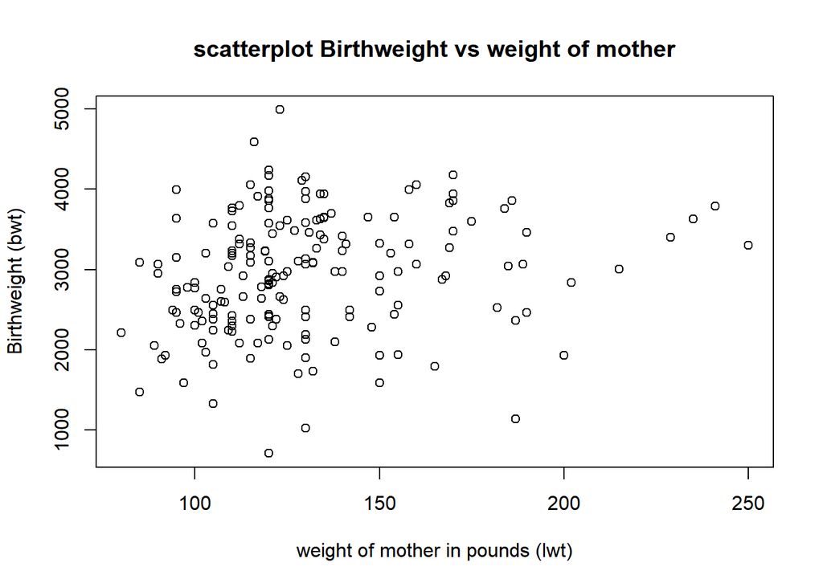

   ```r
   plot(bwt$bwt ~ bwt$lwt, main = "scatterplot Birthweight vs weight of mother",
        ylab = "Birthweight (bwt)", xlab = "weight of mother in pounds (lwt)")
   ```

2. Compute the correlation and interpret the sign and magnitude.

   ```r
   cor.test(bwt$bwt, bwt$lwt)
   ```

   ```
   ##
   ##  Pearson's product-moment correlation
   ##
   ## data:  bwt$bwt and bwt$lwt
   ## t = 2.5848, df = 187, p-value = 0.0105
   ## alternative hypothesis: true correlation is not equal to 0
   ## 95 percent confidence interval:
   ##  0.04417405 0.31998094
   ## sample estimates:
   ##       cor
   ## 0.1857333
   ```

   The positive sign indicates that as maternal weight increases, birth weight tends to increase. However, the magnitude is small (around 0.18), indicating a weak linear relationship.

# 3 Part C — Inferential statistics (15 points)

## 3.1 C1. Fit and interpret a linear model (15 points)

Fit the model

$$\texttt{bwt} \sim \texttt{lwt}.$$

1. Fit the model and print the summary.

   ```r
   fit <- lm(bwt ~ lwt, data = bwt)
   summary(fit)
   ```

   ```
   ##
   ## Call:
   ## lm(formula = bwt ~ lwt, data = bwt)
   ##
   ## Residuals:
   ##      Min       1Q   Median       3Q      Max
   ## -2192.12  -497.97    -3.84   508.32  2075.60
   ##
   ## Coefficients:
   ##             Estimate Std. Error t value Pr(>|t|)
   ## (Intercept) 2369.624    228.493  10.371   <2e-16 ***
   ## lwt            4.429      1.713   2.585   0.0105 *
   ## ---
   ## Signif. codes:  0 '***' 0.001 '**' 0.01 '*' 0.05 '.' 0.1 ' ' 1
   ##
   ## Residual standard error: 718.4 on 187 degrees of freedom
   ## Multiple R-squared:  0.0345, Adjusted R-squared:  0.02933
   ## F-statistic: 6.681 on 1 and 187 DF,  p-value: 0.0105
   ```

2. Write down the estimated regression equation.

   ^bwt=Intercept+steigung*lwt = 2369.624 + 4.429 * lwt
3. Interpret the slope in context (one sentence).

   For each one-unit increase in the mother’s weight (`lwt`), the expected birth weight (`bwt`) increases on average by about **4.43 grams**
4. Add the regression line to your scatterplot.

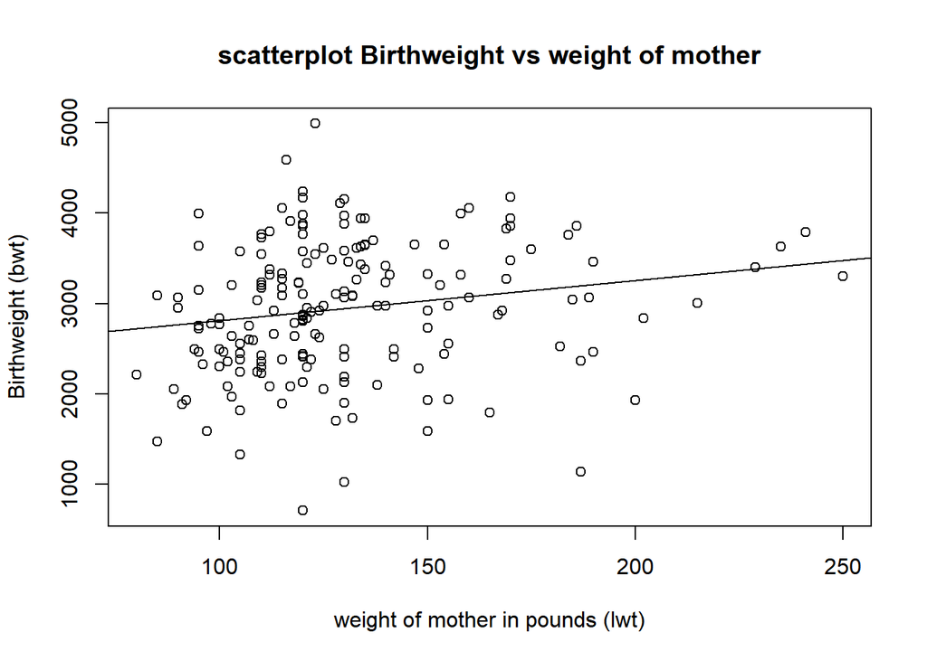

```r
plot(bwt$bwt ~ bwt$lwt, main = "scatterplot Birthweight vs weight of mother",
     ylab = "Birthweight (bwt)", xlab = "weight of mother in pounds (lwt)")
abline(fit)
```

# 4 Submission checklist (not graded)

- The file knits without errors.
- All plots have readable axis labels and titles.
- Each requested interpretation is written in full sentences.